# Fest verankert – Eine Simulationsstudie zu den Voraussetzungen für robustes Test-Equating

Dominik Weber

März 2021

# Loading packages

```r
library(car)
library(catIrt)
library(dplyr)
library(effectsize)
library(equateIRT)
library(ggplot2)
library(jmv)
library(ltm)
library(MOTE)
library(psych)
library(tidyr)
```

# Settings

## Global parameters

In order to simulate data certain parameters need to be entered. The software must know how many cases (N) and how many samples (k) are to be generated. These variables can be be set freely with values bigger than zero. Also, in order to gain reproducible results the randomization seed in R can be fixed.

```r
N = 50
k = 10
set.seed(123456)
```

## IRT specific parameters

Depending on which IRT model you want to simulate data for, different parameters are required. For the 1PL (Rasch) model, item discrimination (a) and guessing parameters (c) are assumed to be constant and are usually fixed to 1 and 0 respectively. Only the item difficulty (b) varies across items and needs to be defined.

```r
a = 1
b = c(rep(-1.34, 20), rep(-0.36, 40), rep(-0.13, 80), rep(1.06, 40), rep(1.87, 20))
c = 0
params = cbind(a, b, c)
rm(a, b, c)
```

# Starting the simulation

## Subsetting the data

In order to estimate how many items are needed for an anchoring approach, in the next step it will be determined which items are solved by which subsample.

```r
for (i in 1:length(sets)) { #for each anchor variant
  currentSet = unlist(sets[i], recursive=F) #extract the testforms
  data = work # make a copy of the data set
  for (j in 1:length(currentSet)) { #for each testform
    currentTest = unlist(currentSet[j], recursive = F) #extract a vector of items from the testform
    data[, 1:200][(N * (j - 1) + 1):(N * j),-currentTest] = NA #set all but the extracted items to NA for a subsample
  }
  if(exists("allSamples")) allSamples = rbind(allSamples, data.frame(data, anchorType = i)) #in the first iteration create the result dataFrame
  else  allSamples = data.frame(data, anchorType = i) #in the following iterations append
}
rm(currentSet, currentTest, data, work)
```

# Running the test equating

```r
resultData = data.frame(realDiff=c(rep(-1.34, 20), rep(-0.36, 40), rep(-0.13, 80), rep(1.06, 40), rep(1.87, 20)))
system.time(
for (i in 1:length(sets)) {
  sample = allSamples[allSamples$anchorType == i,]
  subsamples = split(sample, sample$i)
  subsamples = lapply(subsamples, cleanData)
  if(i < 6) {res = directGetDiff(subsamples)}
  else {res = indirectGetDiff(subsamples,(31 - i))}
  resultData = cbind(resultData, res)
}
)
```

```
##        User      System verstrichen
##       15.97        0.02       16.18
```

```r
resultData$errorAT1 = (resultData[, 3] - resultData[, 1]) ^ 2
resultData$errorAT2 = (resultData[, 5] - resultData[, 1]) ^ 2
resultData$errorAT3 = (resultData[, 7] - resultData[, 1]) ^ 2
resultData$errorAT4 = (resultData[, 9] - resultData[, 1]) ^ 2
resultData$errorAT5 = (resultData[, 11] - resultData[, 1]) ^ 2
resultData$errorAT6 = (resultData[, 13] - resultData[, 1]) ^ 2
resultData$errorAT7 = (resultData[, 15] - resultData[, 1]) ^ 2
resultData$errorAT8 = (resultData[, 17] - resultData[, 1]) ^ 2
resultData$errorAT9 = (resultData[, 19] - resultData[, 1]) ^ 2
resultData$errorAT10 = (resultData[, 21] - resultData[, 1]) ^ 2
psych::describe(resultData[, (ncol(resultData) - 9):ncol(resultData)])
```

```
##           vars   n mean   sd median trimmed  mad min  max range skew kurtosis
## errorAT1     1 200 0.12 0.16   0.05    0.09 0.07   0 1.09  1.09 2.45     8.39
## errorAT2     2 200 0.13 0.17   0.06    0.10 0.08   0 1.17  1.17 2.28     7.24
## errorAT3     3 200 0.11 0.15   0.06    0.08 0.07   0 1.03  1.03 2.78    10.19
## errorAT4     4 200 0.35 0.42   0.17    0.27 0.23   0 2.14  2.14 1.53     1.97
## errorAT5     5 200 0.11 0.14   0.07    0.09 0.09   0 0.84  0.84 2.38     7.27
## errorAT6     6 200 0.13 0.19   0.07    0.10 0.09   0 1.87  1.87 4.33    31.94
## errorAT7     7 200 0.21 0.26   0.13    0.16 0.17   0 1.92  1.92 2.56     9.98
## errorAT8     8 200 0.24 0.30   0.12    0.19 0.17   0 1.53  1.53 1.86     3.95
## errorAT9     9 200 0.83 0.79   0.63    0.72 0.71   0 4.60  4.60 1.26     1.91
## errorAT10   10 200 0.65 0.71   0.38    0.53 0.51   0 3.31  3.31 1.29     1.03
##             se
## errorAT1  0.01
## errorAT2  0.01
## errorAT3  0.01
## errorAT4  0.03
## errorAT5  0.01
## errorAT6  0.01
## errorAT7  0.02
## errorAT8  0.02
## errorAT9  0.06
## errorAT10 0.05
```

## Loading data of all iterations

```r
load("allResults.Rdata")
```

# Analyzing results of the test equating

## Boxplot for estimated Difficulties

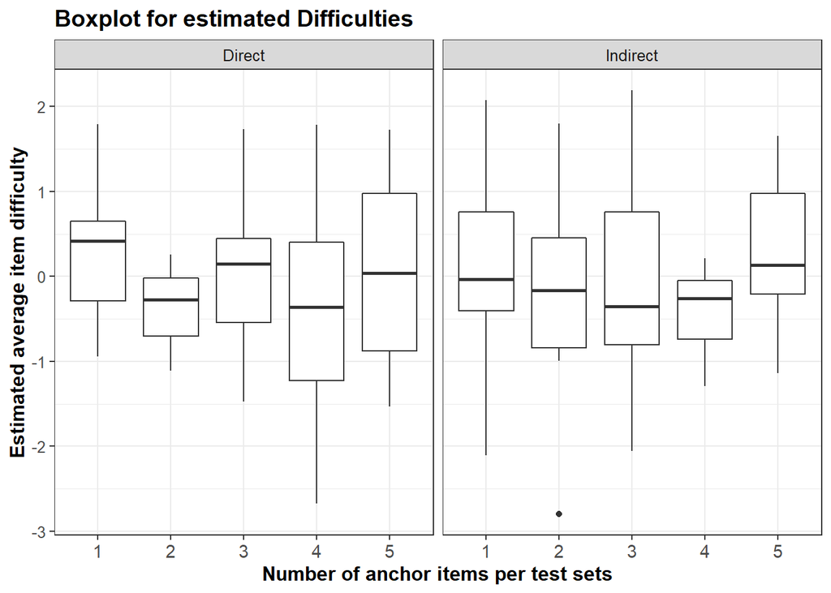

```r
plotData = data.frame(type = c(rep("Direct", 50), rep("Indirect", 50)),
                      anchors = as.factor(rep(1:5, 20)),
                      diff = rnorm(100))
diffPlot = ggplot(plotData, aes(x = anchors, y = diff)) +
  geom_boxplot() +
  scale_y_continuous(name = "Estimated average item difficulty")+
  scale_x_discrete(name = "Number of anchor items per test sets")+
  ggtitle("Boxplot for estimated Difficulties") +
  theme_bw() +
  theme(plot.title = element_text(size = 14, face = "bold"),
        text = element_text(size = 12),
        axis.title = element_text(face = "bold"),
        axis.text.x = element_text(size = 11)) +
  facet_grid(. ~ type)
diffPlot
```

## Creating a 2x5x5 matrix with the 3 factors ET, EV and RA

ET = Equating Type, EV = Equating variant, RA = Number of Rules (Item Difficulty)

```r
Iterations = 1000
estimates = data.frame(matrix(nrow=1000, ncol = 51))
estimates[,1] = 1:1000
colnames(estimates)[1] = "Iteration"
tmpString = ""
for (i in 1:2) {
  for (j in 1:5) {
    for (k in 1:5) {
      if(i == 1) tmpString = paste(paste("d", j, sep = ""), paste("v", k, sep = ""), sep = "_")
      else tmpString = paste(paste("i", j, sep = ""), paste("v", k, sep = ""), sep = "_")
      col = (i - 1) * 25 + (j - 1) * 5 + k + 1
      colnames(estimates)[col] = tmpString
    }
  }
}
rm(i, j, k, col, tmpString)
itemSets = list(1:20, 21:60, 61:140, 141:180, 181:200)
for (it in 1:Iterations) {
  for (set in 1:10) {
    for (rules in 1:5) {
      col = (set - 1) * 5 + rules + 1
      estimates[it, col] = mean(allResults[[it]][itemSets[[rules]], (set + 1)])
    }
  }
}
rm(Iterations, col, it, rules, set, itemSets)
```

## Splitting and trimming data (inner 95 %)

```r
d1_v1 = subset(estimates[2])
d1_v2 = subset(estimates[3])
d1_v3 = subset(estimates[4])
d1_v4 = subset(estimates[5])
d1_v5 = subset(estimates[6])
d2_v1 = subset(estimates[7])
d2_v2 = subset(estimates[8])
d2_v3 = subset(estimates[9])
d2_v4 = subset(estimates[10])
d2_v5 = subset(estimates[11])
d3_v1 = subset(estimates[12])
d3_v2 = subset(estimates[13])
d3_v3 = subset(estimates[14])
d3_v4 = subset(estimates[15])
d3_v5 = subset(estimates[16])
d4_v1 = subset(estimates[17])
d4_v2 = subset(estimates[18])
d4_v3 = subset(estimates[19])
d4_v4 = subset(estimates[20])
d4_v5 = subset(estimates[21])
d5_v1 = subset(estimates[22])
d5_v2 = subset(estimates[23])
d5_v3 = subset(estimates[24])
d5_v4 = subset(estimates[25])
d5_v5 = subset(estimates[26])
i1_v1 = subset(estimates[27])
i1_v2 = subset(estimates[28])
i1_v3 = subset(estimates[29])
i1_v4 = subset(estimates[30])
i1_v5 = subset(estimates[31])
i2_v1 = subset(estimates[32])
i2_v2 = subset(estimates[33])
i2_v3 = subset(estimates[34])
i2_v4 = subset(estimates[35])
i2_v5 = subset(estimates[36])
i3_v1 = subset(estimates[37])
i3_v2 = subset(estimates[38])
i3_v3 = subset(estimates[39])
i3_v4 = subset(estimates[40])
i3_v5 = subset(estimates[41])
i4_v1 = subset(estimates[42])
i4_v2 = subset(estimates[43])
i4_v3 = subset(estimates[44])
i4_v4 = subset(estimates[45])
i4_v5 = subset(estimates[46])
i5_v1 = subset(estimates[47])
i5_v2 = subset(estimates[48])
i5_v3 = subset(estimates[49])
i5_v4 = subset(estimates[50])
i5_v5 = subset(estimates[51])

highCutoff = 0.975
lowCutoff = 1 - highCutoff

d1_v1 = d1_v1 %>% filter(between(d1_v1, quantile(d1_v1, lowCutoff), quantile(d1_v1, highCutoff)))
d1_v2 = d1_v2 %>% filter(between(d1_v2, quantile(d1_v2, lowCutoff), quantile(d1_v2, highCutoff)))
d1_v3 = d1_v3 %>% filter(between(d1_v3, quantile(d1_v3, lowCutoff), quantile(d1_v3, highCutoff)))
d1_v4 = d1_v4 %>% filter(between(d1_v4, quantile(d1_v4, lowCutoff), quantile(d1_v4, highCutoff)))
d1_v5 = d1_v5 %>% filter(between(d1_v5, quantile(d1_v5, lowCutoff), quantile(d1_v5, highCutoff)))
d2_v1 = d2_v1 %>% filter(between(d2_v1, quantile(d2_v1, lowCutoff), quantile(d2_v1, highCutoff)))
d2_v2 = d2_v2 %>% filter(between(d2_v2, quantile(d2_v2, lowCutoff), quantile(d2_v2, highCutoff)))
d2_v3 = d2_v3 %>% filter(between(d2_v3, quantile(d2_v3, lowCutoff), quantile(d2_v3, highCutoff)))
d2_v4 = d2_v4 %>% filter(between(d2_v4, quantile(d2_v4, lowCutoff), quantile(d2_v4, highCutoff)))
d2_v5 = d2_v5 %>% filter(between(d2_v5, quantile(d2_v5, lowCutoff), quantile(d2_v5, highCutoff)))
d3_v1 = d3_v1 %>% filter(between(d3_v1, quantile(d3_v1, lowCutoff), quantile(d3_v1, highCutoff)))
d3_v2 = d3_v2 %>% filter(between(d3_v2, quantile(d3_v2, lowCutoff), quantile(d3_v2, highCutoff)))
d3_v3 = d3_v3 %>% filter(between(d3_v3, quantile(d3_v3, lowCutoff), quantile(d3_v3, highCutoff)))
d3_v4 = d3_v4 %>% filter(between(d3_v4, quantile(d3_v4, lowCutoff), quantile(d3_v4, highCutoff)))
d3_v5 = d3_v5 %>% filter(between(d3_v5, quantile(d3_v5, lowCutoff), quantile(d3_v5, highCutoff)))
d4_v1 = d4_v1 %>% filter(between(d4_v1, quantile(d4_v1, lowCutoff), quantile(d4_v1, highCutoff)))
d4_v2 = d4_v2 %>% filter(between(d4_v2, quantile(d4_v2, lowCutoff), quantile(d4_v2, highCutoff)))
d4_v3 = d4_v3 %>% filter(between(d4_v3, quantile(d4_v3, lowCutoff), quantile(d4_v3, highCutoff)))
d4_v4 = d4_v4 %>% filter(between(d4_v4, quantile(d4_v4, lowCutoff), quantile(d4_v4, highCutoff)))
d4_v5 = d4_v5 %>% filter(between(d4_v5, quantile(d4_v5, lowCutoff), quantile(d4_v5, highCutoff)))
d5_v1 = d5_v1 %>% filter(between(d5_v1, quantile(d5_v1, lowCutoff), quantile(d5_v1, highCutoff)))
d5_v2 = d5_v2 %>% filter(between(d5_v2, quantile(d5_v2, lowCutoff), quantile(d5_v2, highCutoff)))
d5_v3 = d5_v3 %>% filter(between(d5_v3, quantile(d5_v3, lowCutoff), quantile(d5_v3, highCutoff)))
d5_v4 = d5_v4 %>% filter(between(d5_v4, quantile(d5_v4, lowCutoff), quantile(d5_v4, highCutoff)))
d5_v5 = d5_v5 %>% filter(between(d5_v5, quantile(d5_v5, lowCutoff), quantile(d5_v5, highCutoff)))
i1_v1 = i1_v1 %>% filter(between(i1_v1, quantile(i1_v1, lowCutoff), quantile(i1_v1, highCutoff)))
i1_v2 = i1_v2 %>% filter(between(i1_v2, quantile(i1_v2, lowCutoff), quantile(i1_v2, highCutoff)))
i1_v3 = i1_v3 %>% filter(between(i1_v3, quantile(i1_v3, lowCutoff), quantile(i1_v3, highCutoff)))
i1_v4 = i1_v4 %>% filter(between(i1_v4, quantile(i1_v4, lowCutoff), quantile(i1_v4, highCutoff)))
i1_v5 = i1_v5 %>% filter(between(i1_v5, quantile(i1_v5, lowCutoff), quantile(i1_v5, highCutoff)))
i2_v1 = i2_v1 %>% filter(between(i2_v1, quantile(i2_v1, lowCutoff), quantile(i2_v1, highCutoff)))
i2_v2 = i2_v2 %>% filter(between(i2_v2, quantile(i2_v2, lowCutoff), quantile(i2_v2, highCutoff)))
i2_v3 = i2_v3 %>% filter(between(i2_v3, quantile(i2_v3, lowCutoff), quantile(i2_v3, highCutoff)))
i2_v4 = i2_v4 %>% filter(between(i2_v4, quantile(i2_v4, lowCutoff), quantile(i2_v4, highCutoff)))
i2_v5 = i2_v5 %>% filter(between(i2_v5, quantile(i2_v5, lowCutoff), quantile(i2_v5, highCutoff)))
i3_v1 = i3_v1 %>% filter(between(i3_v1, quantile(i3_v1, lowCutoff), quantile(i3_v1, highCutoff)))
i3_v2 = i3_v2 %>% filter(between(i3_v2, quantile(i3_v2, lowCutoff), quantile(i3_v2, highCutoff)))
i3_v3 = i3_v3 %>% filter(between(i3_v3, quantile(i3_v3, lowCutoff), quantile(i3_v3, highCutoff)))
i3_v4 = i3_v4 %>% filter(between(i3_v4, quantile(i3_v4, lowCutoff), quantile(i3_v4, highCutoff)))
i3_v5 = i3_v5 %>% filter(between(i3_v5, quantile(i3_v5, lowCutoff), quantile(i3_v5, highCutoff)))
i4_v1 = i4_v1 %>% filter(between(i4_v1, quantile(i4_v1, lowCutoff), quantile(i4_v1, highCutoff)))
i4_v2 = i4_v2 %>% filter(between(i4_v2, quantile(i4_v2, lowCutoff), quantile(i4_v2, highCutoff)))
i4_v3 = i4_v3 %>% filter(between(i4_v3, quantile(i4_v3, lowCutoff), quantile(i4_v3, highCutoff)))
i4_v4 = i4_v4 %>% filter(between(i4_v4, quantile(i4_v4, lowCutoff), quantile(i4_v4, highCutoff)))
i4_v5 = i4_v5 %>% filter(between(i4_v5, quantile(i4_v5, lowCutoff), quantile(i4_v5, highCutoff)))
i5_v1 = i5_v1 %>% filter(between(i5_v1, quantile(i5_v1, lowCutoff), quantile(i5_v1, highCutoff)))
i5_v2 = i5_v2 %>% filter(between(i5_v2, quantile(i5_v2, lowCutoff), quantile(i5_v2, highCutoff)))
i5_v3 = i5_v3 %>% filter(between(i5_v3, quantile(i5_v3, lowCutoff), quantile(i5_v3, highCutoff)))
i5_v4 = i5_v4 %>% filter(between(i5_v4, quantile(i5_v4, lowCutoff), quantile(i5_v4, highCutoff)))
i5_v5 = i5_v5 %>% filter(between(i5_v5, quantile(i5_v5, lowCutoff), quantile(i5_v5, highCutoff)))
```

## Merging and transforming data frame

```r
estimatesTrimmed = data.frame(d1_v1, d1_v2, d1_v3, d1_v4, d1_v5, d2_v1, d2_v2, d2_v3, d2_v4, d2_v5, d3_v1, d3_v2, d3_v3, d3_v4, d3_v5, d4_v1, d4_v2, d4_v3, d4_v4, d4_v5, d5_v1, d5_v2, d5_v3, d5_v4, d5_v5, i1_v1, i1_v2, i1_v3, i1_v4, i1_v5, i2_v1, i2_v2, i2_v3, i2_v4, i2_v5, i3_v1, i3_v2, i3_v3, i3_v4, i3_v5, i4_v1, i4_v2, i4_v3, i4_v4, i4_v5, i5_v1, i5_v2, i5_v3, i5_v4, i5_v5)

oneColTrimmed <- gather(estimatesTrimmed, key = "key", value = "value")

dfTrimmed = data.frame(type = c(rep(1, 23750), rep(2, 23750)), var = rep(c(rep(5, 4750), rep(4, 4750), rep(3, 4750), rep(2, 4750), rep(1, 4750)), 2), rule = rep(c(rep(1, 950), rep(2, 950), rep(3, 950), rep(4, 950), rep(5, 950)),50), oneColTrimmed)
```

## Descriptive statistics

d = direct equating, i = indirect equating, v = number of rules

```r
describe(estimatesTrimmed[, 1:50])
```

```
##       vars   n mean   sd median trimmed  mad  min  max range skew kurtosis   se
## d1_v1    1 950 0.24 0.13   0.20    0.21 0.10 0.07 0.83  0.75 1.59     2.69 0.00
## d1_v2    2 950 0.17 0.07   0.15    0.16 0.06 0.07 0.45  0.39 1.16     1.31 0.00
## d1_v3    3 950 0.17 0.07   0.15    0.16 0.06 0.07 0.41  0.34 1.12     1.03 0.00
## d1_v4    4 950 0.21 0.09   0.18    0.19 0.07 0.08 0.61  0.52 1.53     2.75 0.00
## d1_v5    5 950 0.32 0.20   0.26    0.28 0.13 0.10 1.34  1.25 2.12     5.65 0.01
## d2_v1    6 950 0.25 0.14   0.21    0.23 0.10 0.08 0.88  0.80 1.62     2.91 0.00
## d2_v2    7 950 0.18 0.08   0.16    0.17 0.07 0.07 0.49  0.42 1.27     1.39 0.00
## d2_v3    8 950 0.18 0.07   0.16    0.17 0.06 0.08 0.48  0.40 1.14     0.97 0.00
## d2_v4    9 950 0.22 0.10   0.19    0.20 0.08 0.09 0.66  0.58 1.60     3.05 0.00
## d2_v5   10 950 0.33 0.20   0.27    0.30 0.13 0.10 1.42  1.32 2.11     5.84 0.01
## d3_v1   11 950 0.26 0.15   0.22    0.24 0.11 0.08 0.83  0.75 1.52     2.26 0.00
## d3_v2   12 950 0.19 0.08   0.17    0.18 0.07 0.07 0.50  0.43 1.19     1.23 0.00
## d3_v3   13 950 0.19 0.08   0.17    0.18 0.07 0.07 0.47  0.40 1.13     0.97 0.00
## d3_v4   14 950 0.23 0.11   0.20    0.21 0.08 0.09 0.69  0.60 1.53     2.68 0.00
## d3_v5   15 950 0.35 0.21   0.29    0.31 0.14 0.11 1.30  1.20 1.83     3.81 0.01
## d4_v1   16 950 0.33 0.20   0.28    0.30 0.15 0.10 1.13  1.03 1.50     2.17 0.01
## d4_v2   17 950 0.26 0.14   0.22    0.24 0.11 0.09 0.74  0.65 1.32     1.49 0.00
## d4_v3   18 950 0.26 0.13   0.22    0.24 0.11 0.09 0.78  0.69 1.37     1.80 0.00
## d4_v4   19 950 0.30 0.16   0.26    0.27 0.12 0.10 0.98  0.87 1.58     2.71 0.01
## d4_v5   20 950 0.41 0.26   0.33    0.36 0.17 0.11 1.66  1.54 1.93     4.39 0.01
## d5_v1   21 950 0.37 0.22   0.31    0.34 0.17 0.11 1.36  1.25 1.58     2.82 0.01
## d5_v2   22 950 0.30 0.16   0.26    0.28 0.12 0.09 0.93  0.83 1.33     1.63 0.01
## d5_v3   23 950 0.30 0.16   0.26    0.28 0.12 0.10 0.92  0.81 1.44     2.04 0.01
## d5_v4   24 950 0.35 0.20   0.30    0.32 0.16 0.11 1.07  0.96 1.36     1.56 0.01
## d5_v5   25 950 0.47 0.29   0.38    0.42 0.21 0.14 1.64  1.50 1.60     2.63 0.01
## i1_v1   26 950 0.24 0.15   0.19    0.21 0.10 0.07 0.87  0.81 1.68     2.91 0.00
## i1_v2   27 950 0.19 0.11   0.16    0.18 0.08 0.07 0.63  0.56 1.59     2.65 0.00
## i1_v3   28 950 0.20 0.10   0.17    0.19 0.08 0.08 0.58  0.50 1.42     1.87 0.00
## i1_v4   29 950 0.23 0.12   0.20    0.21 0.10 0.08 0.69  0.61 1.31     1.55 0.00
## i1_v5   30 950 0.30 0.19   0.25    0.27 0.14 0.08 1.14  1.06 1.68     3.29 0.01
## i2_v1   31 950 0.27 0.18   0.21    0.24 0.12 0.07 1.04  0.96 1.74     3.33 0.01
## i2_v2   32 950 0.22 0.13   0.19    0.20 0.09 0.07 0.74  0.67 1.58     2.60 0.00
## i2_v3   33 950 0.24 0.12   0.20    0.22 0.09 0.09 0.76  0.67 1.54     2.57 0.00
## i2_v4   34 950 0.25 0.14   0.21    0.23 0.11 0.09 0.78  0.69 1.47     2.09 0.00
## i2_v5   35 950 0.33 0.21   0.27    0.29 0.16 0.09 1.23  1.14 1.57     2.59 0.01
## i3_v1   36 950 0.31 0.19   0.26    0.28 0.14 0.09 1.14  1.05 1.74     3.32 0.01
## i3_v2   37 950 0.23 0.13   0.19    0.20 0.09 0.07 0.75  0.68 1.65     2.73 0.00
## i3_v3   38 950 0.23 0.13   0.20    0.21 0.09 0.08 0.73  0.65 1.59     2.43 0.00
## i3_v4   39 950 0.26 0.15   0.21    0.23 0.11 0.08 0.83  0.74 1.49     1.85 0.00
## i3_v5   40 950 0.39 0.24   0.33    0.35 0.17 0.11 1.48  1.36 1.73     3.23 0.01
## i4_v1   41 950 0.40 0.27   0.31    0.36 0.18 0.10 1.38  1.28 1.46     1.74 0.01
## i4_v2   42 950 0.38 0.23   0.31    0.35 0.18 0.11 1.19  1.08 1.31     1.35 0.01
## i4_v3   43 950 0.38 0.22   0.31    0.35 0.18 0.11 1.20  1.08 1.31     1.34 0.01
## i4_v4   44 950 0.42 0.26   0.34    0.38 0.19 0.12 1.35  1.23 1.42     1.68 0.01
## i4_v5   45 950 0.47 0.32   0.36    0.41 0.22 0.11 1.69  1.58 1.61     2.46 0.01
## i5_v1   46 950 0.49 0.31   0.40    0.44 0.23 0.14 1.82  1.68 1.61     2.79 0.01
## i5_v2   47 950 0.43 0.27   0.35    0.39 0.20 0.11 1.49  1.38 1.51     2.20 0.01
## i5_v3   48 950 0.42 0.26   0.34    0.37 0.20 0.11 1.38  1.27 1.42     1.68 0.01
## i5_v4   49 950 0.48 0.30   0.39    0.43 0.22 0.13 1.82  1.70 1.46     2.15 0.01
## i5_v5   50 950 0.61 0.39   0.49    0.54 0.29 0.16 2.47  2.32 1.73     3.57 0.01
```

```r
type1 = subset(estimatesTrimmed[1:25])
type1_oc = gather(type1, key = "key", value = "value")
describe(type1_oc)
```

```
##       vars     n  mean   sd median trimmed  mad  min   max range skew kurtosis
## key*     1 23750 13.00 7.21  13.00   13.00 8.90 1.00 25.00 24.00 0.00    -1.20
## value    2 23750  0.27 0.18   0.22    0.24 0.11 0.07  1.66  1.59 2.33     8.03
##         se
## key*  0.05
## value 0.00
```

```r
mean(type1_oc$value)
```

```
## [1] 0.2728572
```

```r
type2 = subset(estimatesTrimmed[26:50])
type2_oc = gather(type2, key = "key", value = "value")
describe(type2_oc)
```

```
##       vars     n  mean   sd median trimmed  mad  min   max range skew kurtosis
## key*     1 23750 13.00 7.21  13.00   13.00 8.90 1.00 25.00  24.0 0.00    -1.20
## value    2 23750  0.33 0.24   0.26    0.29 0.16 0.07  2.47   2.4 2.17     6.72
##         se
## key*  0.05
## value 0.00
```

```r
mean(type2_oc$value)
```

```
## [1] 0.3346247
```

```r
var1 = subset(estimatesTrimmed[c(1:5, 26:30)])
var1_oc = gather(var1, key = "key", value = "value")
describe(var1_oc)
```

```
##       vars    n mean   sd median trimmed  mad  min   max range skew kurtosis
## key*     1 9500 5.50 2.87   5.50     5.5 3.71 1.00 10.00  9.00 0.00    -1.22
## value    2 9500 0.23 0.14   0.19     0.2 0.09 0.07  1.34  1.28 2.33     8.36
##         se
## key*  0.03
## value 0.00
```

```r
mean(var1_oc$value)
```

```
## [1] 0.2259114
```

```r
var2 = subset(estimatesTrimmed[c(6:10, 31:35)])
var2_oc = gather(var2, key = "key", value = "value")
describe(var2_oc)
```

```
##       vars    n mean   sd median trimmed  mad  min   max range skew kurtosis
## key*     1 9500 5.50 2.87    5.5    5.50 3.71 1.00 10.00  9.00 0.00    -1.22
## value    2 9500 0.25 0.15    0.2    0.22 0.10 0.07  1.42  1.35 2.18     6.95
##         se
## key*  0.03
## value 0.00
```

```r
mean(var2_oc$value)
```

```
## [1] 0.2461361
```

```r
var3 = subset(estimatesTrimmed[c(11:15, 36:40)])
var3_oc = gather(var3, key = "key", value = "value")
describe(var3_oc)
```

```
##       vars    n mean   sd median trimmed  mad  min   max range skew kurtosis
## key*     1 9500 5.50 2.87   5.50    5.50 3.71 1.00 10.00  9.00 0.00    -1.22
## value    2 9500 0.26 0.17   0.21    0.23 0.11 0.07  1.48  1.41 2.23     7.04
##         se
## key*  0.03
## value 0.00
```

```r
mean(var3_oc$value)
```

```
## [1] 0.2631882
```

```r
var4 = subset(estimatesTrimmed[c(16:20, 41:45)])
var4_oc = gather(var4, key = "key", value = "value")
describe(var4_oc)
```

```
##       vars    n mean   sd median trimmed  mad  min   max range skew kurtosis
## key*     1 9500 5.50 2.87   5.50    5.50 3.71 1.00 10.00   9.0 0.00    -1.22
## value    2 9500 0.36 0.24   0.29    0.32 0.16 0.09  1.69   1.6 1.86     4.24
##         se
## key*  0.03
## value 0.00
```

```r
mean(var4_oc$value)
```

```
## [1] 0.3617742
```

```r
var5 = subset(estimatesTrimmed[c(21:25, 46:50)])
var5_oc = gather(var5, key = "key", value = "value")
describe(var5_oc)
```

```
##       vars    n mean   sd median trimmed  mad  min   max range skew kurtosis
## key*     1 9500 5.50 2.87   5.50    5.50 3.71 1.00 10.00  9.00 0.00    -1.22
## value    2 9500 0.42 0.28   0.34    0.37 0.19 0.09  2.47  2.38 1.95     5.33
##         se
## key*  0.03
## value 0.00
```

```r
mean(var5_oc$value)
```

```
## [1] 0.4216948
```

```r
rule1 = subset(estimatesTrimmed[c(1, 6, 11, 16, 21, 26, 31, 36, 41, 46)])
rule1_oc = gather(rule1, key = "key", value = "value")
describe(rule1_oc)
```

```
##       vars    n mean   sd median trimmed  mad  min   max range skew kurtosis
## key*     1 9500 5.50 2.87   5.50    5.50 3.71 1.00 10.00  9.00 0.00    -1.22
## value    2 9500 0.32 0.22   0.25    0.28 0.14 0.07  1.82  1.75 2.03     5.60
##         se
## key*  0.03
## value 0.00
```

```r
mean(rule1_oc$value)
```

```
## [1] 0.3165441
```

```r
rule2 = subset(estimatesTrimmed[c(2, 7, 12, 17, 22, 27, 32, 37, 42, 47)])
rule2_oc = gather(rule2, key = "key", value = "value")
describe(rule2_oc)
```

```
##       vars    n mean   sd median trimmed  mad  min   max range skew kurtosis
## key*     1 9500 5.50 2.87    5.5    5.50 3.71 1.00 10.00  9.00 0.00    -1.22
## value    2 9500 0.26 0.17    0.2    0.22 0.11 0.07  1.49  1.42 2.31     7.51
##         se
## key*  0.03
## value 0.00
```

```r
mean(rule2_oc$value)
```

```
## [1] 0.2560111
```

```r
rule3 = subset(estimatesTrimmed[c(3, 8, 13, 18, 23, 28, 33, 38, 43, 48)])
rule3_oc = gather(rule3, key = "key", value = "value")
describe(rule3_oc)
```

```
##       vars    n mean   sd median trimmed  mad  min   max range skew kurtosis
## key*     1 9500 5.50 2.87    5.5    5.50 3.71 1.00 10.00  9.00  0.0    -1.22
## value    2 9500 0.26 0.17    0.2    0.23 0.10 0.07  1.38  1.31  2.3     7.12
##         se
## key*  0.03
## value 0.00
```

```r
mean(rule3_oc$value)
```

```
## [1] 0.2560264
```

```r
rule4 = subset(estimatesTrimmed[c(4, 9, 14, 19, 24, 29, 34, 39, 44, 49)])
rule4_oc = gather(rule4, key = "key", value = "value")
describe(rule4_oc)
```

```
##       vars    n mean   sd median trimmed  mad  min   max range skew kurtosis
## key*     1 9500 5.50 2.87   5.50    5.50 3.71 1.00 10.00  9.00 0.00    -1.22
## value    2 9500 0.29 0.20   0.23    0.26 0.12 0.08  1.82  1.74 2.25     7.02
##         se
## key*  0.03
## value 0.00
```

```r
mean(rule4_oc$value)
```

```
## [1] 0.2936185
```

```r
rule5 = subset(estimatesTrimmed[c(5, 10, 15, 20, 25, 30, 35, 40, 45, 50)])
rule5_oc = gather(rule5, key = "key", value = "value")
describe(rule5_oc)
```

```
##       vars    n mean   sd median trimmed  mad  min   max range skew kurtosis
## key*     1 9500  5.5 2.87   5.50    5.50 3.71 1.00 10.00  9.00 0.00    -1.22
## value    2 9500  0.4 0.27   0.31    0.35 0.18 0.08  2.47  2.39 2.12     6.21
##         se
## key*  0.03
## value 0.00
```

```r
mean(rule5_oc$value)
```

```
## [1] 0.3965046
```

## ANOVA and contrasts

```r
# Transforming type, var and rule into factors

dfTrimmed$type = as.factor(dfTrimmed$type)
dfTrimmed$var = as.factor(dfTrimmed$var)
dfTrimmed$rule = as.factor(dfTrimmed$rule)

# Defining contrasts

c1 = c(1.5, 1.5, -1, -1, -1) # group contrast
c2 = c(2, -1, -2, -1, 2) # quadratic contrast

mat1 = cbind(c1)
mat2 = cbind(c2)

contrasts(dfTrimmed$var) = mat1
contrasts(dfTrimmed$rule) = mat2

# Conducting ANOVA

options(scipen = 999)
mod.new = aov(value ~ type * var * rule, data = dfTrimmed)
(sum.new = summary.aov(mod.new, split=list(var = list("Group_Comparison" = 1), rule = list("Quadratic" = 1))))
```

```
##                                                 Df Sum Sq Mean Sq   F value
## type                                             1    227   226.5  6145.503
## var                                              4   1344   336.1  9117.457
##   var: Group_Comparison                          1   1226  1226.0 33258.958
## rule                                             4    638   159.4  4325.384
##   rule: Quadratic                                1    451   450.6 12223.430
## type:var                                         4    107    26.7   725.210
##   type:var: Group_Comparison                     1     96    96.1  2605.930
## type:rule                                        4      8     2.0    54.415
##   type:rule: Quadratic                           1      8     7.8   210.427
## var:rule                                        16     20     1.3    34.228
##   var:rule: Group_Comparison.Quadratic           1      0     0.0     0.009
## type:var:rule                                   16     13     0.8    21.210
##   type:var:rule: Group_Comparison.Quadratic      1      0     0.1     2.481
## Residuals                                   237450   8753     0.0
##                                                          Pr(>F)
## type                                        <0.0000000000000002 ***
## var                                         <0.0000000000000002 ***
##   var: Group_Comparison                     <0.0000000000000002 ***
## rule                                        <0.0000000000000002 ***
##   rule: Quadratic                           <0.0000000000000002 ***
## type:var                                    <0.0000000000000002 ***
##   type:var: Group_Comparison                <0.0000000000000002 ***
## type:rule                                   <0.0000000000000002 ***
##   type:rule: Quadratic                      <0.0000000000000002 ***
## var:rule                                    <0.0000000000000002 ***
##   var:rule: Group_Comparison.Quadratic                    0.925
## type:var:rule                               <0.0000000000000002 ***
##   type:var:rule: Group_Comparison.Quadratic               0.115
## Residuals
## ---
## Signif. codes:  0 '***' 0.001 '**' 0.01 '*' 0.05 '.' 0.1 ' ' 1
```

```r
omega_squared(mod.new)
```

[output not shown]

```r
# Creating a table of the statistics from the ANOVA with more digits

Factor = c("ET", "EV", "EV_contrast", "RA", "RA_trend", "ET x EV", "-", "ET x RA", "-", "EV x RA", "-", "ET x EV x RA", "-", "Residual")
Degrees = round(as.numeric(sum.new[[1]]$Df), digits = 10)
Sum_Square = round(as.numeric(sum.new[[1]]$`Sum Sq`), digits = 10)
Mean_Square = round(as.numeric(sum.new[[1]]$`Mean Sq`), digits = 10)
F_Value = round(as.numeric(sum.new[[1]]$`F value`), digits = 10)
p_Value = round(as.numeric(sum.new[[1]]$`Pr(>F)`), digits = 10)
(df_ANOVA = data.frame(Factor, Degrees, Sum_Square, Mean_Square, F_Value, p_Value))
```

```
##          Factor Degrees      Sum_Square     Mean_Square        F_Value
## 1            ET       1  226.5285716219  226.5285716219  6145.50326634
## 2            EV       4 1344.3094846832  336.0773711708  9117.45731448
## 3   EV_contrast       1 1225.9539917622 1225.9539917622 33258.95805023
## 4            RA       4  637.7495313983  159.4373828496  4325.38354903
## 5      RA_trend       1  450.5662092832  450.5662092832 12223.42987918
## 6       ET x EV       4  106.9274055542   26.7318513885   725.20953471
## 7             -       1   96.0568524928   96.0568524928  2605.93044189
## 8       ET x RA       4    8.0231609940    2.0057902485    54.41516907
## 9             -       1    7.7565313058    7.7565313058   210.42726811
## 10      EV x RA      16   20.1867696174    1.2616731011    34.22798329
## 11            -       1    0.0003231282    0.0003231282     0.00876616
## 12 ET x EV x RA      16   12.5088455094    0.7818028443    21.20956266
## 13            -       1    0.0914544882    0.0914544882     2.48107271
## 14     Residual  237450 8752.6126015211    0.0368608659             NA
##      p_Value
## 1  0.0000000
## 2  0.0000000
## 3  0.0000000
## 4  0.0000000
## 5  0.0000000
## 6  0.0000000
## 7  0.0000000
## 8  0.0000000
## 9  0.0000000
## 10 0.0000000
## 11 0.9254049
## 12 0.0000000
## 13 0.1152250
## 14        NA
```

```r
# Calculating contrasts

jmv::ANOVA(formula = value ~ type * var * rule, data = dfTrimmed, effectSize = "omega", postHoc = ~ type * var * rule, contrasts = list(list(var = "rule", type = "polynomial"), list(var = "var", type = "polynomial")))
```

```
## NOTE: Results may be misleading due to involvement in interactions
## NOTE: Results may be misleading due to involvement in interactions
## NOTE: Results may be misleading due to involvement in interactions
```

```
##
##  ANOVA
##
##  ANOVA - value
##  ------------------------------------------------------------------------------------------------------
##                     Sum of Squares    df        Mean Square     F             p             ω²
##  ------------------------------------------------------------------------------------------------------
##    type                 226.528572         1    226.52857162    6145.50327    < .0000001    0.0203883
##    var                 1344.309485         4    336.07737117    9117.45731    < .0000001    0.1209988
##    rule                 637.749531         4    159.43738285    4325.38355    < .0000001    0.0573957
##    type:var             106.927406         4     26.73185139     725.20953    < .0000001    0.0096121
##    type:rule              8.023161         4      2.00579025      54.41517    < .0000001    0.0007090
##    var:rule              20.186770        16      1.26167310      34.22798    < .0000001    0.0017641
##    type:var:rule         12.508846        16      0.78180284      21.20956    < .0000001    0.0010729
##    Residuals           8752.612602    237450      0.03686087
##  ------------------------------------------------------------------------------------------------------
##
##
##  CONTRASTS
##
##  Contrasts - rule
##  -----------------------------------------------------------------------
##                 Estimate       SE             t             p
##  -----------------------------------------------------------------------
##    linear       0.062463944    8.809190e-4     70.907707    < .0000001
##    quadratic    0.097394068    8.809190e-4    110.559621    < .0000001
##    cubic        0.001500723    8.809190e-4      1.703588     0.0884593
##    quartic      0.006058470    8.809190e-4      6.877443    < .0000001
##  -----------------------------------------------------------------------
##
##
##  Contrasts - var
##  -----------------------------------------------------------------------
##                 Estimate       SE             t             p
##  -----------------------------------------------------------------------
##    linear       -0.16039227    8.809190e-4    -182.07380    < .0000001
##    quadratic     0.04300921    8.809190e-4      48.82312    < .0000001
##    cubic         0.01122381    8.809190e-4      12.74102    < .0000001
##    quartic      -0.02449096    8.809190e-4     -27.80160    < .0000001
##  -----------------------------------------------------------------------
```

[output cut: 32 more lines]

```
##  --------------------------------------------------------------------------------------------------
##    rule         rule    Mean Difference    SE             df          t                p-tukey
##  --------------------------------------------------------------------------------------------------
##    1       -    2            0.06053306    0.001245808    237450.0      48.58941648    < .0000001
##            -    3            0.06051777    0.001245808    237450.0      48.57714364    < .0000001
##            -    4            0.02292568    0.001245808    237450.0      18.40226168    < .0000001
##            -    5           -0.07996047    0.001245808    237450.0     -64.18364888    < .0000001
##    2       -    3          -1.528960e-5    0.001245808    237450.0      -0.01227284     1.0000000
##            -    4           -0.03760739    0.001245808    237450.0     -30.18715480    < .0000001
##            -    5           -0.14049354    0.001245808    237450.0    -112.77306537    < .0000001
##    3       -    4           -0.03759210    0.001245808    237450.0     -30.17488196    < .0000001
##            -    5           -0.14047825    0.001245808    237450.0    -112.76079252    < .0000001
##    4       -    5           -0.10288615    0.001245808    237450.0     -82.58591057    < .0000001
##  --------------------------------------------------------------------------------------------------
##    Note. Comparisons are based on estimated marginal means
```

```r
TukeyHSD(mod.new, "var")
```

```
##   Tukey multiple comparisons of means
##     95% family-wise confidence level
##
## Fit: aov(formula = value ~ type * var * rule, data = dfTrimmed)
##
## $var
##            diff         lwr         upr p adj
## 2-1 -0.05992058 -0.06331887 -0.05652230     0
## 3-1 -0.15850662 -0.16190490 -0.15510834     0
## 4-1 -0.17555868 -0.17895696 -0.17216040     0
## 5-1 -0.19578339 -0.19918168 -0.19238511     0
## 3-2 -0.09858604 -0.10198432 -0.09518776     0
## 4-2 -0.11563810 -0.11903638 -0.11223981     0
## 5-2 -0.13586281 -0.13926109 -0.13246453     0
## 4-3 -0.01705206 -0.02045034 -0.01365377     0
## 5-3 -0.03727677 -0.04067505 -0.03387849     0
## 5-4 -0.02022471 -0.02362300 -0.01682643     0
```

```r
# Calculating the mean differences of the contrasts

(x1 = (mean(var1_oc$value) + mean(var2_oc$value) + mean(var3_oc$value))/3)
```

```
## [1] 0.2450786
```

```r
(x2 = (mean(var4_oc$value) + mean(var5_oc$value))/2)
```

```
## [1] 0.3917345
```

# Effect sizes (Omega squared)

```r
ss_total = 226.5285716219 + 1344.3094846830 + 637.7495313988 + 106.9274055542 + 8.0231609941 + 20.1867696174 + 12.5088455094 + 8752.6126015211

omega.full.SS(dfm = 1, dfe = 237450,
msm = 226.5285716219, mse = 0.0368608659,
sst = (ss_total), a = .05) # ET
```

```
## $omega
## [1] 0.02038834
##
## $omegalow
## [1] 0.01927794
##
## $omegahigh
## [1] 0.02152825
##
## $dfm
## [1] 1
##
## $dfe
## [1] 237450
##
## $F
## [1] 6145.503
##
## $p
## [1] 0
##
## $estimate
## [1] "$\\omega^2$ = 0.02, 95\\% CI [0.02, 0.02]"
##
## $statistic
## [1] "$F$(1, 237450) = 6145.50, $p$ < .001"
```

```r
omega.full.SS(dfm = 4, dfe = 237450,
msm = 336.0773711708, mse = 0.0368608659,
sst = (ss_total), a = .05) # EV
```

```
## $omega
## [1] 0.1209988
##
## $omegalow
## [1] 0.1185368
##
## $omegahigh
## [1] 0.1234558
##
## $dfm
## [1] 4
##
## $dfe
## [1] 237450
##
## $F
## [1] 9117.457
##
## $p
## [1] 0
##
## $estimate
## [1] "$\\omega^2$ = 0.12, 95\\% CI [0.12, 0.12]"
##
## $statistic
## [1] "$F$(4, 237450) = 9117.46, $p$ < .001"
```

```r
omega.full.SS(dfm = 1, dfe = 237450,
msm = 1225.9539917622, mse = 0.0368608659,
sst = (ss_total), a = .05) # EV Contrast
```

```
## $omega
## [1] 0.1103547
##
## $omegalow
## [1] 0.1079865
##
## $omegahigh
## [1] 0.1127413
##
## $dfm
## [1] 1
##
## $dfe
## [1] 237450
##
## $F
## [1] 33258.96
##
## $p
## [1] 0
##
## $estimate
## [1] "$\\omega^2$ = 0.11, 95\\% CI [0.11, 0.11]"
##
## $statistic
## [1] "$F$(1, 237450) = 33258.96, $p$ < .001"
```

```r
omega.full.SS(dfm = 4, dfe = 237450,
msm = 159.4373828497, mse = 0.0368608659,
sst = (ss_total), a = .05) # RA
```

```
## $omega
## [1] 0.0573957
##
## $omegalow
## [1] 0.0555796
##
## $omegahigh
## [1] 0.05921261
##
## $dfm
## [1] 4
##
## $dfe
## [1] 237450
##
## $F
## [1] 4325.384
##
## $p
## [1] 0
##
## $estimate
## [1] "$\\omega^2$ = 0.06, 95\\% CI [0.06, 0.06]"
##
## $statistic
## [1] "$F$(4, 237450) = 4325.38, $p$ < .001"
```

```r
omega.full.SS(dfm = 1, dfe = 237450,
msm = 450.5662092836, mse = 0.0368608659,
sst = (ss_total), a = .05) # RA Trend
```

```
## $omega
## [1] 0.04055577
##
## $omegalow
## [1] 0.03901502
##
## $omegahigh
## [1] 0.04212352
##
## $dfm
## [1] 1
##
## $dfe
## [1] 237450
##
## $F
## [1] 12223.43
##
## $p
## [1] 0
##
## $estimate
## [1] "$\\omega^2$ = 0.04, 95\\% CI [0.04, 0.04]"
##
## $statistic
## [1] "$F$(1, 237450) = 12223.43, $p$ < .001"
```

```r
omega.full.SS(dfm = 4, dfe = 237450,
msm = 26.7318513886, mse = 0.0368608659,
sst = (ss_total), a = .05) # ET x EV
```

```
## $omega
## [1] 0.009612124
##
## $omegalow
## [1] 0.008834271
##
## $omegahigh
## [1] 0.01039603
##
## $dfm
## [1] 4
##
## $dfe
## [1] 237450
##
## $F
## [1] 725.2095
##
## $p
## [1] 0
##
## $estimate
## [1] "$\\omega^2$ = 0.01, 95\\% CI [0.01, 0.01]"
##
## $statistic
## [1] "$F$(4, 237450) = 725.21, $p$ < .001"
```

```r
omega.full.SS(dfm = 4, dfe = 237450,
msm = 2.0057902485, mse = 0.0368608659,
sst = (ss_total), a = .05) # ET x RA
```

```
## $omega
## [1] 0.0007089567
##
## $omegalow
## [1] 0.000499413
##
## $omegahigh
## [1] 0.0009255854
##
## $dfm
## [1] 4
##
## $dfe
## [1] 237450
##
## $F
## [1] 54.41517
##
## $p
## [1] 0.0000000000000000000000000000000000000000000006274255
##
## $estimate
## [1] "$\\omega^2$ = 0.00, 95\\% CI [0.00, 0.00]"
##
## $statistic
## [1] "$F$(4, 237450) = 54.42, $p$ < .001"
```

```r
omega.full.SS(dfm = 16, dfe = 237450,
msm = 1.2616731011, mse = 0.0368608659,
sst = (ss_total), a = .05) # EV x RA
```

```
## $omega
## [1] 0.001764083
##
## $omegalow
## [1] 0.001382901
##
## $omegahigh
## [1] 0.002051396
##
## $dfm
## [1] 16
##
## $dfe
## [1] 237450
##
## $F
## [1] 34.22798
##
## $p
## [1] 0.0000000000000000000000000000000000000000000000000000000000000000000000000000000000000000000000000000000003809817
##
## $estimate
## [1] "$\\omega^2$ = 0.00, 95\\% CI [0.00, 0.00]"
##
## $statistic
## [1] "$F$(16, 237450) = 34.23, $p$ < .001"
```

```r
omega.full.SS(dfm = 16, dfe = 237450,
msm = 0.7818028443, mse = 0.0368608659,
sst = (ss_total), a = .05) # ET x EV x RA
```

```
## $omega
## [1] 0.001072932
##
## $omegalow
## [1] 0.0007667393
##
## $omegahigh
## [1] 0.001285358
##
## $dfm
## [1] 16
##
## $dfe
## [1] 237450
##
## $F
## [1] 21.20956
##
## $p
## [1] 0.00000000000000000000000000000000000000000000000000000000000001913833
##
## $estimate
## [1] "$\\omega^2$ = 0.00, 95\\% CI [0.00, 0.00]"
##
## $statistic
## [1] "$F$(16, 237450) = 21.21, $p$ < .001"
```

```r
omega.full.SS(dfm = 1, dfe = 237450,
msm = 16.2^2 * 0.0368608659, mse = 0.0368608659,
sst = (ss_total), a = .05) # v5v4
```

```
## $omega
## [1] 0.0008674954
##
## $omegalow
## [1] 0.0006468746
##
## $omegahigh
## [1] 0.001120313
##
## $dfm
## [1] 1
##
## $dfe
## [1] 237450
##
## $F
## [1] 262.44
##
## $p
## [1] 0.00000000000000000000000000000000000000000000000000000000005424664
##
## $estimate
## [1] "$\\omega^2$ = 0.00, 95\\% CI [0.00, 0.00]"
##
## $statistic
## [1] "$F$(1, 237450) = 262.44, $p$ < .001"
```

```r
omega.full.SS(dfm = 1, dfe = 237450,
msm = 29.9^2 * 0.0368608659, mse = 0.0368608659,
sst = (ss_total), a = .05) # v5v3
```

```
## $omega
## [1] 0.002963135
##
## $omegalow
## [1] 0.002542537
##
## $omegahigh
## [1] 0.003415684
##
## $dfm
## [1] 1
##
## $dfe
## [1] 237450
##
## $F
## [1] 894.01
##
## $p
## [1] 0.000000000000000000000000000000000000000000000000000000000000…
##
## $estimate
## [1] "$\\omega^2$ = 0.00, 95\\% CI [0.00, 0.00]"
##
## $statistic
## [1] "$F$(1, 237450) = 894.01, $p$ < .001"
```

```r
omega.full.SS(dfm = 1, dfe = 237450,
msm = 109.1^2 * 0.0368608659, mse = 0.0368608659,
sst = (ss_total), a = .05) # v5v2
```

```
## $omega
## [1] 0.03949191
##
## $omegalow
## [1] 0.03797004
##
## $omegahigh
## [1] 0.04104086
##
## $dfm
## [1] 1
##
## $dfe
## [1] 237450
##
## $F
## [1] 11902.81
##
## $p
## [1] 0
##
## $estimate
## [1] "$\\omega^2$ = 0.04, 95\\% CI [0.04, 0.04]"
##
## $statistic
## [1] "$F$(1, 237450) = 11902.81, $p$ < .001"
```

```r
omega.full.SS(dfm = 1, dfe = 237450,
msm = 157.2^2 * 0.0368608659, mse = 0.0368608659,
sst = (ss_total), a = .05) # v5v1
```

```
## $omega
## [1] 0.08199411
##
## $omegalow
## [1] 0.07989038
##
## $omegahigh
## [1] 0.08411967
##
## $dfm
## [1] 1
##
## $dfe
## [1] 237450
##
## $F
## [1] 24711.84
##
## $p
## [1] 0
##
## $estimate
## [1] "$\\omega^2$ = 0.08, 95\\% CI [0.08, 0.08]"
##
## $statistic
## [1] "$F$(1, 237450) = 24711.84, $p$ < .001"
```

```r
omega.full.SS(dfm = 1, dfe = 237450,
msm = 13.7^2 * 0.0368608659, mse = 0.0368608659,
sst = (ss_total), a = .05) # v4v3
```

```
## $omega
## [1] 0.0006194642
##
## $omegalow
## [1] 0.000435517
##
## $omegahigh
## [1] 0.0008357018
##
## $dfm
## [1] 1
##
## $dfe
## [1] 237450
##
## $F
## [1] 187.69
##
## $p
## [1] 0.000000000000000000000000000000000000000001053999
##
## $estimate
## [1] "$\\omega^2$ = 0.00, 95\\% CI [0.00, 0.00]"
##
## $statistic
## [1] "$F$(1, 237450) = 187.69, $p$ < .001"
```

```r
omega.full.SS(dfm = 1, dfe = 237450,
msm = 92.8^2 * 0.0368608659, mse = 0.0368608659,
sst = (ss_total), a = .05) # v4v2
```

```
## $omega
## [1] 0.028572
##
## $omegalow
## [1] 0.0272653
##
## $omegahigh
## [1] 0.02990721
##
## $dfm
## [1] 1
##
## $dfe
## [1] 237450
##
## $F
## [1] 8611.84
##
## $p
## [1] 0
##
## $estimate
## [1] "$\\omega^2$ = 0.03, 95\\% CI [0.03, 0.03]"
##
## $statistic
## [1] "$F$(1, 237450) = 8611.84, $p$ < .001"
```

```r
omega.full.SS(dfm = 1, dfe = 237450,
msm = 140.9^2 * 0.0368608659, mse = 0.0368608659,
sst = (ss_total), a = .05) # v4v1
```

```
## $omega
## [1] 0.06587115
##
## $omegalow
## [1] 0.06395427
##
## $omegahigh
## [1] 0.06781164
##
## $dfm
## [1] 1
##
## $dfe
## [1] 237450
##
## $F
## [1] 19852.81
##
## $p
## [1] 0
##
## $estimate
## [1] "$\\omega^2$ = 0.07, 95\\% CI [0.06, 0.07]"
##
## $statistic
## [1] "$F$(1, 237450) = 19852.81, $p$ < .001"
```

```r
omega.full.SS(dfm = 1, dfe = 237450,
msm = 79.1^2 * 0.0368608659, mse = 0.0368608659,
sst = (ss_total), a = .05) # v3v2
```

```
## $omega
## [1] 0.02075767
##
## $omegalow
## [1] 0.01963759
##
## $omegahigh
## [1] 0.02190733
##
## $dfm
## [1] 1
##
## $dfe
## [1] 237450
##
## $F
## [1] 6256.81
##
## $p
## [1] 0
##
## $estimate
## [1] "$\\omega^2$ = 0.02, 95\\% CI [0.02, 0.02]"
##
## $statistic
## [1] "$F$(1, 237450) = 6256.81, $p$ < .001"
```

```r
omega.full.SS(dfm = 1, dfe = 237450,
msm = 127.2^2 * 0.0368608659, mse = 0.0368608659,
sst = (ss_total), a = .05) # v3v1
```

```
## $omega
## [1] 0.05368371
##
## $omegalow
## [1] 0.05193252
##
## $omegahigh
## [1] 0.05546015
##
## $dfm
## [1] 1
##
## $dfe
## [1] 237450
##
## $F
## [1] 16179.84
##
## $p
## [1] 0
##
## $estimate
## [1] "$\\omega^2$ = 0.05, 95\\% CI [0.05, 0.06]"
##
## $statistic
## [1] "$F$(1, 237450) = 16179.84, $p$ < .001"
```

```r
omega.full.SS(dfm = 1, dfe = 237450,
msm = 48.1^2 * 0.0368608659, mse = 0.0368608659,
sst = (ss_total), a = .05) # v2v1
```

```
## $omega
## [1] 0.007673571
##
## $omegalow
## [1] 0.006989988
##
## $omegahigh
## [1] 0.00838843
##
## $dfm
## [1] 1
##
## $dfe
## [1] 237450
##
## $F
## [1] 2313.61
##
## $p
## [1] 0
##
## $estimate
## [1] "$\\omega^2$ = 0.01, 95\\% CI [0.01, 0.01]"
##
## $statistic
## [1] "$F$(1, 237450) = 2313.61, $p$ < .001"
```

```r
omega.full.SS(dfm = 1, dfe = 237450,
msm = 48.5894^2 * 0.0368608659, mse = 0.0368608659,
sst = (ss_total), a = .05) # r1r2
```

```
## $omega
## [1] 0.007830585
##
## $omegalow
## [1] 0.007139953
##
## $omegahigh
## [1] 0.008552461
##
## $dfm
## [1] 1
##
## $dfe
## [1] 237450
##
## $F
## [1] 2360.93
##
## $p
## [1] 0
##
## $estimate
## [1] "$\\omega^2$ = 0.01, 95\\% CI [0.01, 0.01]"
##
## $statistic
## [1] "$F$(1, 237450) = 2360.93, $p$ < .001"
```

```r
omega.full.SS(dfm = 1, dfe = 237450,
msm = 48.5771^2 * 0.0368608659, mse = 0.0368608659,
sst = (ss_total), a = .05) # r1r3
```

```
## $omega
## [1] 0.007826619
##
## $omegalow
## [1] 0.007136139
##
## $omegahigh
## [1] 0.008548289
##
## $dfm
## [1] 1
##
## $dfe
## [1] 237450
##
## $F
## [1] 2359.735
##
## $p
## [1] 0
##
## $estimate
## [1] "$\\omega^2$ = 0.01, 95\\% CI [0.01, 0.01]"
##
## $statistic
## [1] "$F$(1, 237450) = 2359.73, $p$ < .001"
```

```r
omega.full.SS(dfm = 1, dfe = 237450,
msm = 18.4023^2 * 0.0368608659, mse = 0.0368608659,
sst = (ss_total), a = .05) # r1r4
```

```
## $omega
## [1] 0.001120353
##
## $omegalow
## [1] 0.0008675008
##
## $omegahigh
## [1] 0.001405402
##
## $dfm
## [1] 1
##
## $dfe
## [1] 237450
##
## $F
## [1] 338.6446
##
## $p
## [1] 0.000000000000000000000000000000000000000000000000000000000000000000000000001421481
##
## $estimate
## [1] "$\\omega^2$ = 0.00, 95\\% CI [0.00, 0.00]"
##
## $statistic
## [1] "$F$(1, 237450) = 338.64, $p$ < .001"
```

```r
omega.full.SS(dfm = 1, dfe = 237450,
msm = 64.1836^2 * 0.0368608659, mse = 0.0368608659,
sst = (ss_total), a = .05) # r1r5
```

```
## $omega
## [1] 0.01366589
##
## $omegalow
## [1] 0.01275363
##
## $omegahigh
## [1] 0.01460864
##
## $dfm
## [1] 1
##
## $dfe
## [1] 237450
##
## $F
## [1] 4119.535
##
## $p
## [1] 0
##
## $estimate
## [1] "$\\omega^2$ = 0.01, 95\\% CI [0.01, 0.01]"
##
## $statistic
## [1] "$F$(1, 237450) = 4119.53, $p$ < .001"
```

```r
omega.full.SS(dfm = 1, dfe = 237450,
msm = 0.0123^2 * 0.0368608659, mse = 0.0368608659,
sst = (ss_total), a = .05) # r2r3
```

```
## $omega
## [1] -0.000003317641
##
## $omegalow
## [1] 0
##
## $omegahigh
## [1] 0.9999952
##
## $dfm
## [1] 1
##
## $dfe
## [1] 237450
##
## $F
## [1] 0.00015129
##
## $p
## [1] 0.9901863
##
## $estimate
## [1] "$\\omega^2$ = 0.00, 95\\% CI [0.00, 1.00]"
##
## $statistic
## [1] "$F$(1, 237450) = 0.00, $p$ = .990"
```

```r
omega.full.SS(dfm = 1, dfe = 237450,
msm = 30.1872^2 * 0.0368608659, mse = 0.0368608659,
sst = (ss_total), a = .05) # r2r4
```

```
## $omega
## [1] 0.003020396
##
## $omegalow
## [1] 0.002595585
##
## $omegahigh
## [1] 0.003477136
##
## $dfm
## [1] 1
##
## $dfe
## [1] 237450
##
## $F
## [1] 911.267
##
## $p
## [1] 0.000000000000000000000000000000000000000000000000000000000000…
##
## $estimate
## [1] "$\\omega^2$ = 0.00, 95\\% CI [0.00, 0.00]"
##
## $statistic
## [1] "$F$(1, 237450) = 911.27, $p$ < .001"
```

```r
omega.full.SS(dfm = 1, dfe = 237450,
msm = 112.7731^2 * 0.0368608659, mse = 0.0368608659,
sst = (ss_total), a = .05) # r2r5
```

```
## $omega
## [1] 0.04219607
##
## $omegalow
## [1] 0.04062673
##
## $omegahigh
## [1] 0.04379221
##
## $dfm
## [1] 1
##
## $dfe
## [1] 237450
##
## $F
## [1] 12717.77
##
## $p
## [1] 0
##
## $estimate
## [1] "$\\omega^2$ = 0.04, 95\\% CI [0.04, 0.04]"
##
## $statistic
## [1] "$F$(1, 237450) = 12717.77, $p$ < .001"
```

```r
omega.full.SS(dfm = 1, dfe = 237450,
msm = 30.1479^2 * 0.0368608659, mse = 0.0368608659,
sst = (ss_total), a = .05) # r3r4
```

```
## $omega
## [1] 0.003012529
##
## $omegalow
## [1] 0.002588313
##
## $omegahigh
## [1] 0.003468672
##
## $dfm
## [1] 1
##
## $dfe
## [1] 237450
##
## $F
## [1] 908.8959
##
## $p
## [1] 0.000000000000000000000000000000000000000000000000000000000000…
##
## $estimate
## [1] "$\\omega^2$ = 0.00, 95\\% CI [0.00, 0.00]"
##
## $statistic
## [1] "$F$(1, 237450) = 908.90, $p$ < .001"
```

```r
omega.full.SS(dfm = 1, dfe = 237450,
msm = 112.7608^2 * 0.0368608659, mse = 0.0368608659,
sst = (ss_total), a = .05) # r3r5
```

```
## $omega
## [1] 0.04218687
##
## $omegalow
## [1] 0.04061767
##
## $omegahigh
## [1] 0.04378267
##
## $dfm
## [1] 1
##
## $dfe
## [1] 237450
##
## $F
## [1] 12715
##
## $p
## [1] 0
##
## $estimate
## [1] "$\\omega^2$ = 0.04, 95\\% CI [0.04, 0.04]"
##
## $statistic
## [1] "$F$(1, 237450) = 12715.00, $p$ < .001"
```

```r
omega.full.SS(dfm = 1, dfe = 237450,
msm = 82.5859^2 * 0.0368608659, mse = 0.0368608659,
sst = (ss_total), a = .05) # r4r5
```

```
## $omega
## [1] 0.02262785
##
## $omegalow
## [1] 0.02145982
##
## $omegahigh
## [1] 0.02382517
##
## $dfm
## [1] 1
##
## $dfe
## [1] 237450
##
## $F
## [1] 6820.431
##
## $p
## [1] 0
##
## $estimate
## [1] "$\\omega^2$ = 0.02, 95\\% CI [0.02, 0.02]"
##
## $statistic
## [1] "$F$(1, 237450) = 6820.43, $p$ < .001"
```

# Plotting data

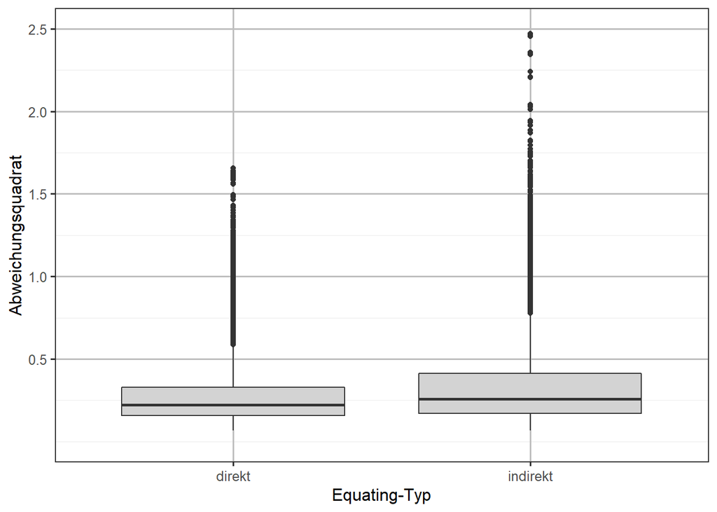

```r
ggplot(dfTrimmed, aes(x = type, y = value, fill = type))  +
  ylim(0, 2.5) +
  theme_bw(base_size = 12) +
  theme(panel.grid.major = element_line(colour = "grey")) +
  geom_boxplot() +
  scale_x_discrete(labels = c("direkt", "indirekt")) +
  scale_y_continuous(breaks=c(0.5, 1, 1.5, 2, 2.5), limits = c(0,2.5)) +
  scale_fill_manual(values = c(rep("lightgrey", 2))) +
  labs(x = "Equating-Typ", y = "Abweichungsquadrat") +
  guides(fill=FALSE)
```

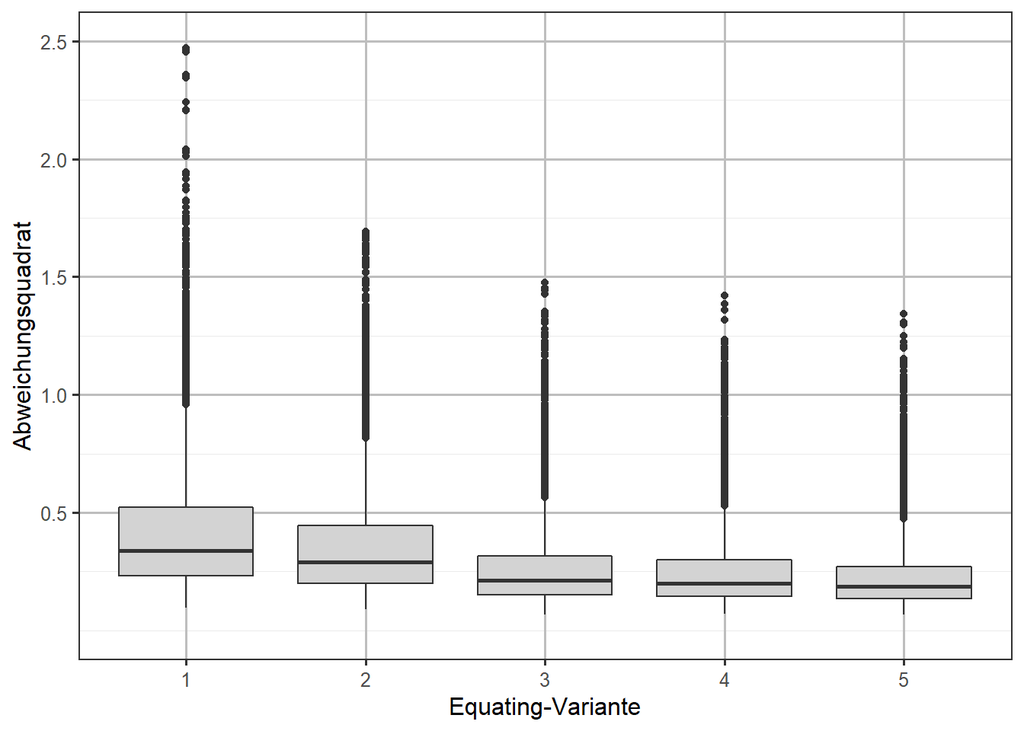

```r
ggplot(dfTrimmed, aes(x = var, y = value, fill = var))  +
  ylim(0, 2.5) +
  theme_bw(base_size = 12) +
  theme(panel.grid.major = element_line(colour = "grey")) +
  geom_boxplot() +
  scale_x_discrete() +
  scale_y_continuous(breaks=c(0.5, 1, 1.5, 2, 2.5), limits = c(0,2.5)) +
  scale_fill_manual(values = c(rep("lightgrey", 5))) +
  labs(x = "Equating-Variante", y = "Abweichungsquadrat") +
  guides(fill=FALSE)
```

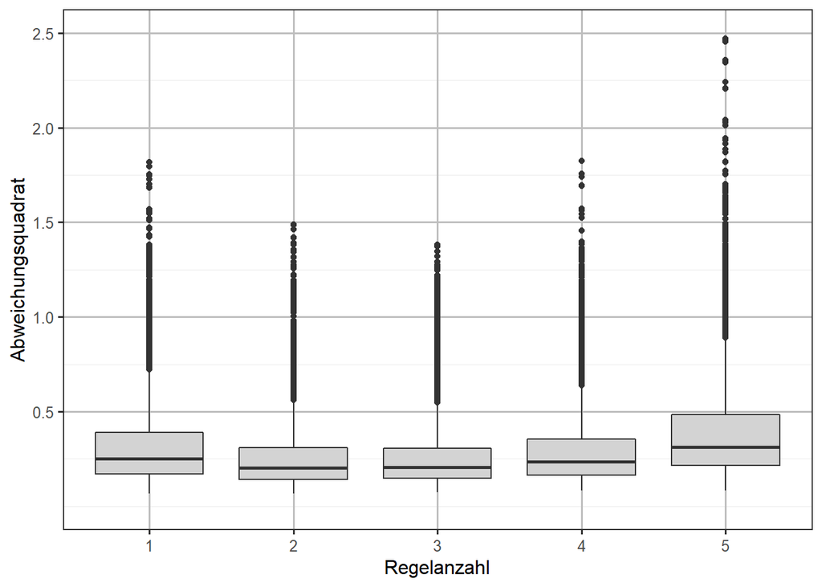

```r
ggplot(dfTrimmed, aes(x = rule, y = value, fill = rule))  +
  ylim(0, 2.5) +
  theme_bw(base_size = 12) +
  theme(panel.grid.major = element_line(colour = "grey")) +
  geom_boxplot() +
  scale_x_discrete() +
  scale_y_continuous(breaks=c(0.5, 1, 1.5, 2, 2.5), limits = c(0,2.5)) +
  scale_fill_manual(values = c(rep("lightgrey", 5))) +
  labs(x = "Regelanzahl", y = "Abweichungsquadrat") +
  guides(fill=FALSE)
```

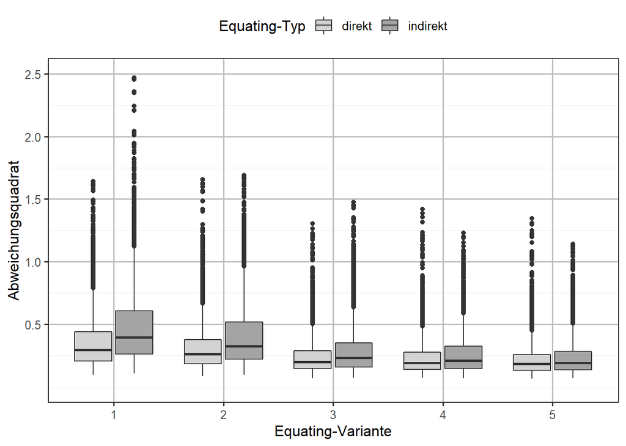

```r
ggplot(dfTrimmed, aes(x = var, y = value, fill = type))  +
  ylim(0, 2.5) +
  theme_bw(base_size = 12) +
  theme(panel.grid.major = element_line(colour = "grey"), legend.position = "top") +
  geom_boxplot() +
  scale_x_discrete() +
  scale_y_continuous(breaks=c(0.5, 1, 1.5, 2, 2.5), limits = c(0,2.5)) +
  scale_fill_manual(values = c("lightgrey", "#A4A4A4"), labels = c("direkt", "indirekt")) +
  labs(x = "Equating-Variante", y = "Abweichungsquadrat", fill = "Equating-Typ")
```

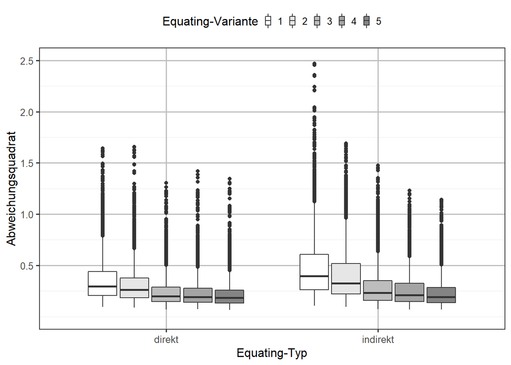

```r
ggplot(dfTrimmed, aes(x = type, y = value, fill = var))  +
  ylim(0, 2.5) +
  theme_bw(base_size = 12) +
  theme(panel.grid.major = element_line(colour = "grey"), legend.position = "top", legend.key.width = unit(0.25,"cm")) +
  geom_boxplot() +
  scale_x_discrete(labels = c("direkt", "indirekt")) +
  scale_y_continuous(breaks=c(0.5, 1, 1.5, 2, 2.5), limits = c(0,2.5)) +
  #scale_fill_manual(values = c("#A9BCF5", "#F5A9A9", "#F2F5A9", "#A9F5A9", "#F5D0A9")) +
  scale_fill_manual(values = c("#FFFFFF", "#E6E6E6", "#BDBDBD", "#A4A4A4", "#848484")) +
  labs(x = "Equating-Typ", y = "Abweichungsquadrat", fill = "Equating-Variante")
```